# week_12_features_interaction

## CMPINF 2100 Week 12

### Working with LINEAR MODELS with INTERACTION features

Lets read in the data we created in the PREVIOUS ADDITIVE features demonstration.

## Import Modules

```python
import numpy as np
import pandas as pd
import matplotlib.pyplot as plt

import seaborn as sns
```

```python
import statsmodels.formula.api as smf
```

```python
import statsmodels.api as sm
```

## Read data

```python
df = pd.read_csv("linear_additive_example.csv")
```

```python
df.info()
```

```
<class 'pandas.core.frame.DataFrame'>
RangeIndex: 35 entries, 0 to 34
Data columns (total 4 columns):
 #   Column  Non-Null Count  Dtype
---  ------  --------------  -----
 0   x1      35 non-null     float64
 1   x2      35 non-null     float64
 2   trend   35 non-null     float64
 3   y       35 non-null     float64
dtypes: float64(4)
memory usage: 1.2 KB
```

```python
df.head()
```

|  | x1 | x2 | trend | y |
| --- | --- | --- | --- | --- |
| 0 | 1.024252 | -0.650623 | 1.617167 | 1.547730 |
| 1 | -1.733671 | 0.993904 | -3.431878 | -3.988479 |
| 2 | -0.089294 | 0.251805 | -0.373762 | -0.107839 |
| 3 | -1.093748 | 1.356543 | -2.111500 | -2.594083 |
| 4 | 0.320995 | -0.145121 | 0.346917 | -0.583119 |

## Fit linear model with INTERACTIONS

The formula interface has several STRANGE and WEIRD...YET..quite useful syntax artifacts when working with INTERACTIONS.

```python
fit_a = smf.ols(formula="y ~ x1 + x2 + x1*x2", data=df).fit()
```

```python
fit_a.summary()
```

OLS Regression Results

| Dep. Variable: | y | R-squared: | 0.889 |
| --- | --- | --- | --- |
| Model: | OLS | Adj. R-squared: | 0.878 |
| Method: | Least Squares | F-statistic: | 82.92 |
| Date: | Sat, 16 Nov 2024 | Prob (F-statistic): | 6.69e-15 |
| Time: | 00:36:48 | Log-Likelihood: | -34.349 |
| No. Observations: | 35 | AIC: | 76.70 |
| Df Residuals: | 31 | BIC: | 82.92 |
| Df Model: | 3 |  |  |
| Covariance Type: | nonrobust |  |  |

|  | coef | std err | t | P>\|t\| | [0.025 | 0.975] |
| --- | --- | --- | --- | --- | --- | --- |
| Intercept | -0.1073 | 0.120 | -0.894 | 0.378 | -0.352 | 0.137 |
| x1 | 1.7486 | 0.136 | 12.823 | 0.000 | 1.470 | 2.027 |
| x2 | 0.1749 | 0.132 | 1.325 | 0.195 | -0.094 | 0.444 |
| x1:x2 | 0.2649 | 0.129 | 2.052 | 0.049 | 0.002 | 0.528 |

| Omnibus: | 0.099 | Durbin-Watson: | 2.090 |
| --- | --- | --- | --- |
| Prob(Omnibus): | 0.952 | Jarque-Bera (JB): | 0.313 |
| Skew: | 0.036 | Prob(JB): | 0.855 |
| Kurtosis: | 2.542 | Cond. No. | 1.98 |

Notes:  
[1] Standard Errors assume that the covariance matrix of the errors is correctly specified.

Lets use the FORMULA INTERFACES actual syntax for the MULTIPLICATION or INTERACTION FEATURE.

```python
fit_b = smf.ols(formula="y ~ x1 + x2 + x1:x2", data=df).fit()
```

```python
fit_b.summary()
```

OLS Regression Results

| Dep. Variable: | y | R-squared: | 0.889 |
| --- | --- | --- | --- |
| Model: | OLS | Adj. R-squared: | 0.878 |
| Method: | Least Squares | F-statistic: | 82.92 |
| Date: | Sat, 16 Nov 2024 | Prob (F-statistic): | 6.69e-15 |
| Time: | 00:38:37 | Log-Likelihood: | -34.349 |
| No. Observations: | 35 | AIC: | 76.70 |
| Df Residuals: | 31 | BIC: | 82.92 |
| Df Model: | 3 |  |  |
| Covariance Type: | nonrobust |  |  |

|  | coef | std err | t | P>\|t\| | [0.025 | 0.975] |
| --- | --- | --- | --- | --- | --- | --- |
| Intercept | -0.1073 | 0.120 | -0.894 | 0.378 | -0.352 | 0.137 |
| x1 | 1.7486 | 0.136 | 12.823 | 0.000 | 1.470 | 2.027 |
| x2 | 0.1749 | 0.132 | 1.325 | 0.195 | -0.094 | 0.444 |
| x1:x2 | 0.2649 | 0.129 | 2.052 | 0.049 | 0.002 | 0.528 |

| Omnibus: | 0.099 | Durbin-Watson: | 2.090 |
| --- | --- | --- | --- |
| Prob(Omnibus): | 0.952 | Jarque-Bera (JB): | 0.313 |
| Skew: | 0.036 | Prob(JB): | 0.855 |
| Kurtosis: | 2.542 | Cond. No. | 1.98 |

Notes:  
[1] Standard Errors assume that the covariance matrix of the errors is correctly specified.

The FORMULA interface creates a SHORTCUT to INCLUDE MAIN EFFECTS **AND** INTERACTIONS in the model!!

The SHORTCUT is to use the `*` operator in the FORMULA interface!!!

```python
fit_c = smf.ols(formula="y ~ x1*x2", data=df).fit()
```

```python
fit_c.summary()
```

OLS Regression Results

| Dep. Variable: | y | R-squared: | 0.889 |
| --- | --- | --- | --- |
| Model: | OLS | Adj. R-squared: | 0.878 |
| Method: | Least Squares | F-statistic: | 82.92 |
| Date: | Sat, 16 Nov 2024 | Prob (F-statistic): | 6.69e-15 |
| Time: | 00:40:37 | Log-Likelihood: | -34.349 |
| No. Observations: | 35 | AIC: | 76.70 |
| Df Residuals: | 31 | BIC: | 82.92 |
| Df Model: | 3 |  |  |
| Covariance Type: | nonrobust |  |  |

|  | coef | std err | t | P>\|t\| | [0.025 | 0.975] |
| --- | --- | --- | --- | --- | --- | --- |
| Intercept | -0.1073 | 0.120 | -0.894 | 0.378 | -0.352 | 0.137 |
| x1 | 1.7486 | 0.136 | 12.823 | 0.000 | 1.470 | 2.027 |
| x2 | 0.1749 | 0.132 | 1.325 | 0.195 | -0.094 | 0.444 |
| x1:x2 | 0.2649 | 0.129 | 2.052 | 0.049 | 0.002 | 0.528 |

| Omnibus: | 0.099 | Durbin-Watson: | 2.090 |
| --- | --- | --- | --- |
| Prob(Omnibus): | 0.952 | Jarque-Bera (JB): | 0.313 |
| Skew: | 0.036 | Prob(JB): | 0.855 |
| Kurtosis: | 2.542 | Cond. No. | 1.98 |

Notes:  
[1] Standard Errors assume that the covariance matrix of the errors is correctly specified.

```python
fit_c.params == fit_b.params
```

```
Intercept    True
x1           True
x2           True
x1:x2        True
dtype: bool
```

```python
fit_c.bse == fit_b.bse
```

```
Intercept    True
x1           True
x2           True
x1:x2        True
dtype: bool
```

```python
fit_c.pvalues == fit_b.pvalues
```

```
Intercept    True
x1           True
x2           True
x1:x2        True
dtype: bool
```

This means if we would ONLY want PRODUCTS then we should use the `:` operator in the FORMULA.

```python
fit_df = smf.ols(formula="y ~ x1:x2", data=df).fit()
```

```python
fit_df.summary()
```

OLS Regression Results

| Dep. Variable: | y | R-squared: | 0.282 |
| --- | --- | --- | --- |
| Model: | OLS | Adj. R-squared: | 0.260 |
| Method: | Least Squares | F-statistic: | 12.95 |
| Date: | Sat, 16 Nov 2024 | Prob (F-statistic): | 0.00103 |
| Time: | 00:45:26 | Log-Likelihood: | -67.053 |
| No. Observations: | 35 | AIC: | 138.1 |
| Df Residuals: | 33 | BIC: | 141.2 |
| Df Model: | 1 |  |  |
| Covariance Type: | nonrobust |  |  |

|  | coef | std err | t | P>\|t\| | [0.025 | 0.975] |
| --- | --- | --- | --- | --- | --- | --- |
| Intercept | 0.0069 | 0.287 | 0.024 | 0.981 | -0.578 | 0.592 |
| x1:x2 | 0.9397 | 0.261 | 3.599 | 0.001 | 0.408 | 1.471 |

| Omnibus: | 0.981 | Durbin-Watson: | 1.509 |
| --- | --- | --- | --- |
| Prob(Omnibus): | 0.612 | Jarque-Bera (JB): | 0.238 |
| Skew: | 0.062 | Prob(JB): | 0.888 |
| Kurtosis: | 3.385 | Cond. No. | 1.14 |

Notes:  
[1] Standard Errors assume that the covariance matrix of the errors is correctly specified.

There is ONE MORE way of representing the SHORTCUT and this is related to the WHY we need to use the np.power() when we want to RAISE an input to a polynomial degree.

```python
df.x1.head()**2
```

```
0    1.049092
1    3.005615
2    0.007973
3    1.196285
4    0.103038
Name: x1, dtype: float64
```

```python
np.power(df.x1.head().to_numpy(), 2)
```

```
array([1.04909217, 3.00561521, 0.00797335, 1.19628455, 0.10303796])
```

```python
fit_e = smf.ols(formula="y ~ x1**2 + x2**2", data=df).fit()
```

```python
fit_e.params
```

```
Intercept   -0.109888
x1           1.879500
x2           0.075586
dtype: float64
```

```python
fit_f = smf.ols(formula="y ~ x1 + x2", data=df).fit()
```

```python
fit_f.params
```

```
Intercept   -0.109888
x1           1.879500
x2           0.075586
dtype: float64
```

In the FORMULA interface, the `**` or POWER operator denotes the DEGREE of INTERACTION between the INPUTS!!!

You cannot use the `**` to RAISE an input to a POWER!!!

```python
fit_g = smf.ols(formula="y ~ np.power(x1, 2) + np.power(x2, 2)", data=df).fit()
```

```python
fit_g.params
```

```
Intercept          0.023664
np.power(x1, 2)    0.468992
np.power(x2, 2)   -0.573997
dtype: float64
```

```python
fit_h = smf.ols(formula="y ~ x1+ np.power(x1, 2) + x2 + np.power(x2, 2)", data=df).fit()
```

```python
fit_h.params
```

```
Intercept         -0.133105
x1                 1.844778
np.power(x1, 2)    0.085897
x2                 0.072746
np.power(x2, 2)   -0.058627
dtype: float64
```

A shortcut is that you can CREATE up to and INCLUDING ALL DEGREE OF INTERACTIONS using the `**` operator in the FORMULA interface!!!!

```python
fit_i = smf.ols(formula="y ~ (x1 + x2)**2", data=df).fit()
```

```python
fit_i.params
```

```
Intercept   -0.107266
x1           1.748614
x2           0.174882
x1:x2        0.264916
dtype: float64
```

You can use this notation to create very COMPLEX interactions between many different types of FEATURES!!!

Thus, you can even INTERACT non-linear features together!!!

```python
fit_j = smf.ols(formula="y ~ (x1 + np.power(x1, 2) + x2 + np.power(x2, 2))**2", data=df).fit()
```

```python
fit_j.params
```

```
Intercept                          0.143433
x1                                 1.043322
np.power(x1, 2)                   -0.363776
x2                                 0.044654
np.power(x2, 2)                   -0.219340
x1:np.power(x1, 2)                 0.230775
x1:x2                             -0.214390
x1:np.power(x2, 2)                 0.484325
np.power(x1, 2):x2                -0.154070
np.power(x1, 2):np.power(x2, 2)    0.482368
x2:np.power(x2, 2)                -0.063944
dtype: float64
```

When you want to INTERACT polynomials...I like to separate the POLYNOMIALS derived from each input using `()` in the formula interface!!!

```python
fit_k = smf.ols(formula="y ~ (x1 + np.power(x1, 2)) * (x2 + np.power(x2, 2))", data=df).fit()
```

```python
fit_k.params
```

```
Intercept                          0.048390
x1                                 1.355946
np.power(x1, 2)                   -0.287992
x2                                -0.030340
np.power(x2, 2)                   -0.061388
x1:x2                             -0.229695
x1:np.power(x2, 2)                 0.641887
np.power(x1, 2):x2                -0.229303
np.power(x1, 2):np.power(x2, 2)    0.458874
dtype: float64
```

## Make Predictions

You do NOT need to create the interactions features yourself!!

You only need to define the INPUTS and the model object will generate all necessary features for you...because the FORMULA INTERFACE **REMEMBERS** what to do!!!

We learned how to create a GRID of combinations of the INPUTS!!

```python
input_grid = pd.DataFrame([(x1, x2) for x1 in np.linspace(df.x1.min(), df.x1.max(), num=101)
                                    for x2 in np.linspace(df.x2.min(), df.x2.max(), num=9)],
                          columns=["x1", "x2"])
```

```python
input_grid
```

|  | x1 | x2 |
| --- | --- | --- |
| 0 | -1.733671 | -1.813330 |
| 1 | -1.733671 | -1.269344 |
| 2 | -1.733671 | -0.725357 |
| 3 | -1.733671 | -0.181371 |
| 4 | -1.733671 | 0.362615 |
| ... | ... | ... |
| 904 | 1.822354 | 0.362615 |
| 905 | 1.822354 | 0.906601 |
| 906 | 1.822354 | 1.450587 |
| 907 | 1.822354 | 1.994573 |
| 908 | 1.822354 | 2.538560 |

909 rows × 2 columns

```python
viz_grid = input_grid.copy()
```

PREDICT the AVERAGE OUTPUT or TREND using the last model we fit.

```python
viz_grid["pred"] = fit_k.predict(viz_grid)
```

```python
viz_grid
```

|  | x1 | x2 | pred |
| --- | --- | --- | --- |
| 0 | -1.733671 | -1.813330 | -1.911260 |
| 1 | -1.733671 | -1.269344 | -2.429809 |
| 2 | -1.733671 | -0.725357 | -2.827037 |
| 3 | -1.733671 | -0.181371 | -3.102943 |
| 4 | -1.733671 | 0.362615 | -3.257528 |
| ... | ... | ... | ... |
| 904 | 1.822354 | 0.362615 | 1.470184 |
| 905 | 1.822354 | 0.906601 | 2.629134 |
| 906 | 1.822354 | 1.450587 | 5.345968 |
| 907 | 1.822354 | 1.994573 | 9.620687 |
| 908 | 1.822354 | 2.538560 | 15.453291 |

909 rows × 3 columns

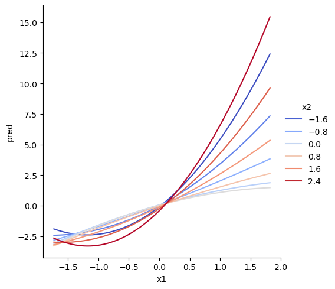

```python
sns.relplot(data=viz_grid,
            x="x1",
            y="pred",
            kind="line",
            hue="x2",
            palette="coolwarm",
            estimator=None,
            units="x2")

plt.show()
```